# Student Name: Homoud Alghanim

# Student ID: 2132131306

# Result:

# 1. Variables identification

| Column Name | Variable definition | Data Type | Missing data report | distribution of the data | level of analysis |
| --- | --- | --- | --- | --- | --- |
| eventid | The incidents ID from the Global Terrorism Database | Discrete(int64) | False | smallest first event id 197000000001 and the last 201701270001 | Event |
| year | The year which the incident accured | Continues(int64) | False | Left Skewed | Event |
| month | The month which the incident accured | Continues(int64) | False | Left Skewed | Event |
| day | The Day which the incident accured | Continues(int64) | False | Right Skewed | Event |
| extended | The duration of an incident if it extended more than 24h or not | String | False | No Distribution | Event |
| summary | An information's summary of the incident | String | True(66138) | No Distribution | Event |
| Criterion_1 | If the goal was for those things(political, economic, religious, or social goal) if it's 0 then was for something else. | String | False | No Distribution | Event |
| Criterion_2 | If the goal was for those things(intention to coerce, intimidate, or publicize to larger audiences) if it's 0 then was for something else. | String | False | No Distribution | Event |
| Criterion_3 | If then the goal was something outside the international humanitarian law | String | False | No Distribution | Event |
| doubt_terr | If there's a doubt whether the incident is an act of terrorism. | String | False | No Distribution | Event |
| multiple | If the attack is part of a multiple incident | String | False | No Distribution | Event |
| related | The event ID related to this event if it was from multiple attacks | String | True(147505) | No Distribution | Event |
| city | The City where the incident occurred | String | True(446) | No Distribution | City |
| country | The Country where the incident occurred | String | False | No Distribution | Country |
| region | The Region where the incident occurred | String | False | No Distribution | Region |
| attacktype_1 | The method of attack happened in the event | String | False | No Distribution | Event |
| attacktype_2 | The method of attack happened in the event | String | True(164720) | No Distribution | Event |
| success | If the strike hasn't been stopped before it happened then it count as success | String | False | No Distribution | Event |
| weaptype | The type of weapon used in the event | String | False | No Distribution | Event |
| targ_type | The main target the terrorist want to strike | String | False | No Distribution | Event |
| targ_subtype | The sub target the terrorist want to strike | String | True(9345) | No Distribution | Event |
| nationality | The nationality of the terrorist or group that occured the event | String | True(1394) | No Distribution | Country |
| group_name | The name of group whom responsible for the event | String | False | No Distribution | Group |
| kills_num | The number of people who died in the event | Continues(int64) | True(9682) | minimum kills 0 and maximum 1500 | Event |
| wounded_num | The number of people who got wounded in the event | Continues(int64) | True(15325) | min 0 wounded maximum 7366 | Event |
| latitude | The latitude of the city the event occurred in | Continues(float) | True(4606) | Left Skewed | Event |
| longitude | The longitude of the city the event occurred in | Continues(float) | True(4606) | Left Skewed | Event |

# 2.

### Transformed Variables

| Variable Names | Variable description | Steps in transformation | level of analysis |
| --- | --- | --- | --- |
| crit_all' | It's an easy approuch for the thee column's(Criterion_1, Criterion_2, Criterion_3) joind them in one place | By applying the val function to go through multiple conditions | Event |
| top5_attacked_region | Has the information for the top 5 attacked regions | By getting the head of the value_counts and using isin while adding them | Region |
| top5_attacked_countries | The most 5 attacked countries informations | By getting the head of the value_counts and using isin while adding them | Country |
| top5_attacked_cities | The most 5 attacked cities informations | By getting the head of the value_counts and using isin while adding them | City |
| top5_target_nationality | The most 5 targeted nationalities informations | By getting the head of the value_counts and using isin while adding them | Country |
| top5_attacktype | The top 5 used attack types | By getting the head of the value_counts and using isin while adding them | Event |
| top5_target_type | The top 5 targeted types of people | By getting the head of the value_counts and using isin while adding them | Event |
| top5_target_Subtype | The top 5 Sub-targeted types of people | By getting the head of the value_counts and using isin while adding them | Event |
| top5_target_grpName | The top 5 active group named responsible for the event's | By getting the head of the value_counts and using isin while adding them | Group |

# 3.

### insights:

[output not shown]

#### World plot of the most countries effected from terrorist

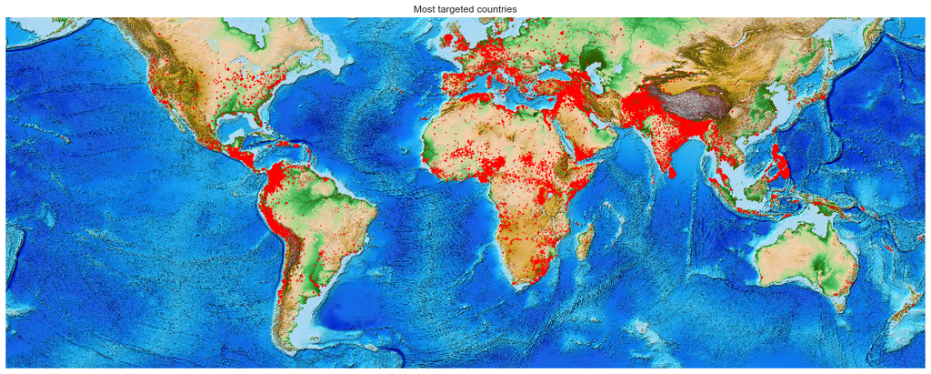

#### Why the numbers of killed people in 2001 increased very much from Taliban and from Al-Shabaab in 2007?

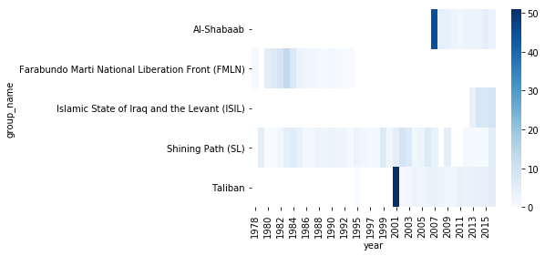

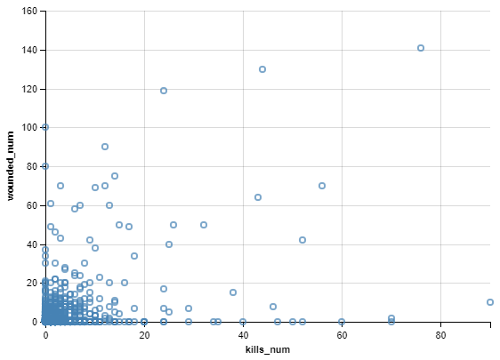

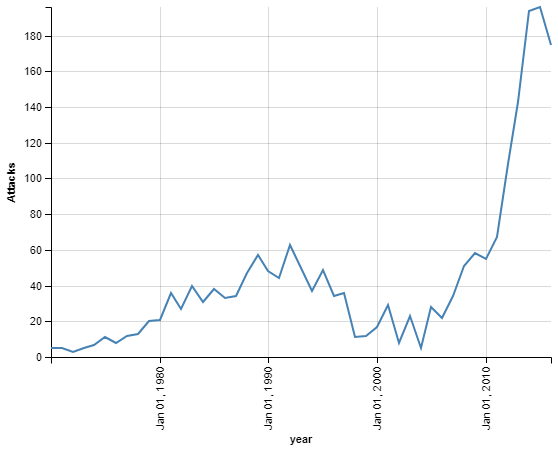

#### The graph shows that May, August and november are the highest, maybe because of the holidays?

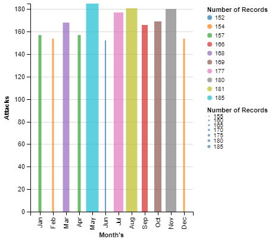

#### 89.05% the operations of the terrorist succeeded

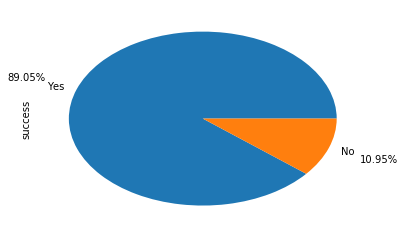

#### less than 5% of the strikes in the database, event's stayed more than 24 hour

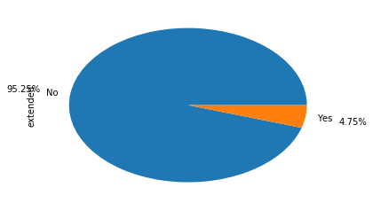

#### We can see that most attacks choose all the three:

#### Criterion_1 (political, economic, religious, or social goal),

#### Criterion_2 (intention to coerce, intimidate, or publicize to larger audiences)

#### Criterion_3 Something outside the international humanitarian law

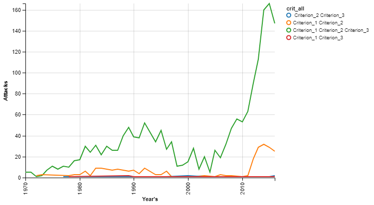

#### The Middle East and North Africa are the most attacked region

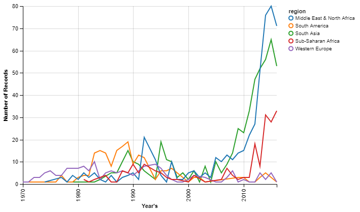

#### The most active month in the Middle east & North Africa is july

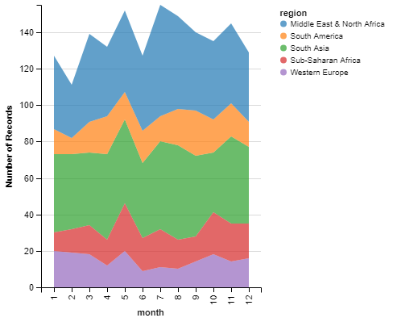

#### Iraq attacks increased after saddam hussain death in 2003

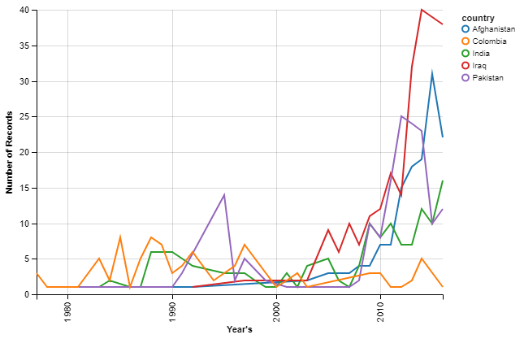

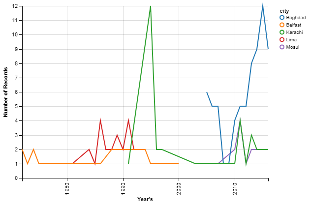

#### The percentage of the attacks on those nationality

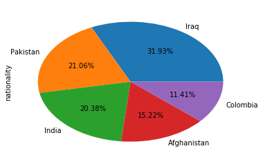

#### Even after the event's extended more than 24 hour there's small amount still doubting if it's a terrorism attack or not

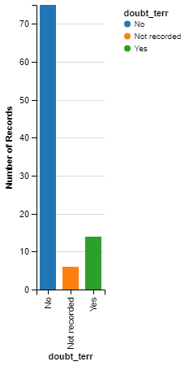

#### The event which is part of multiple event's spiked after 2011

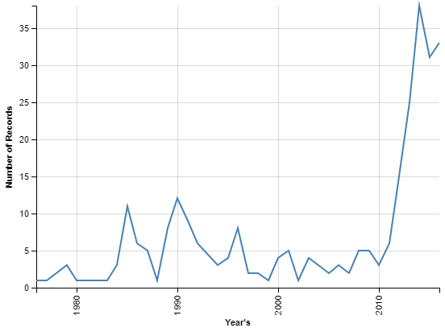

#### Lima and Baghdad got the most multiple event's

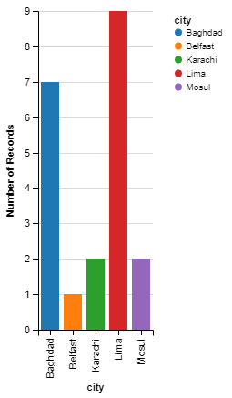

#### Baghdad got bombed the most then Karachi got Armed assault the most

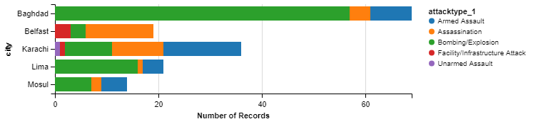

#### The highest nationalities who got multiple event's are Iraqis and India

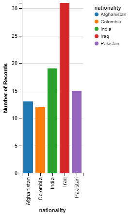

#### The Kidnapping attack type looks like the most frequent one used in the event's that extends for more than 24 hour's

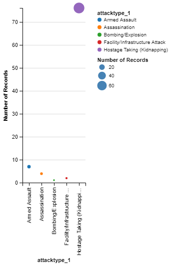

#### most attacks target type are Private Citizens & Property

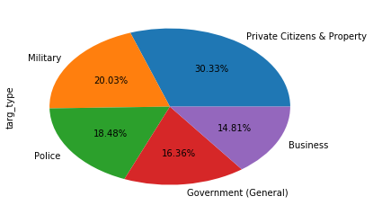

#### we can see that the ISIL and Taliban the most active groups

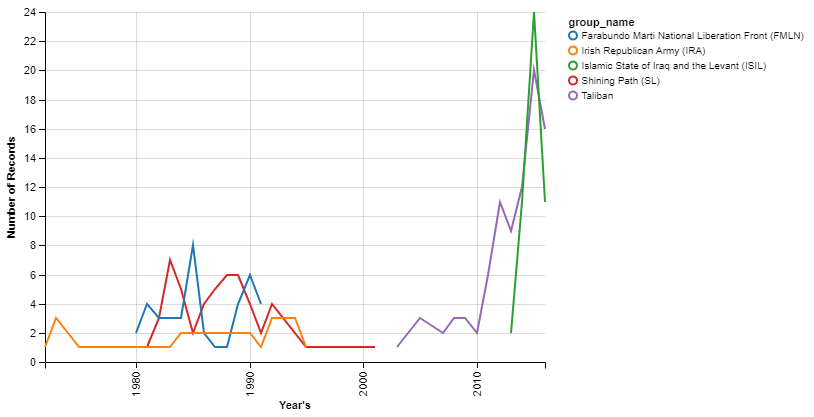

# 4.

### Question's:

- Why all the terrorist activities increased mostly after 2010?
- Can we predict about when the next attack if we feed this information to a machine?
- The countries with the less damage and attacks are they good at defending themselves or they're not targeted?
- Why the numbers of killed people in 2001 increased very much from Taliban and from Al-Shabaab in 2007?

[figure not shown]